# Tricot Resources

## Publications

## Training Videos

## Costing Templates

## Supporting Material

## Publications

### The Tricot Guide

Jacob van Etten, Rhys Manners, Jonathan Steinke, Elsa Matthus, Kauê de Sousa. 2020. The tricot approach. Guide for large-scale participatory experiments. Rome (Italy): Alliance of Bioversity International and CIAT. https://hdl.handle.net/10568/109942

This is a short, full-colour guide intended for practitioners who are not yet familiar with tricot. It explains the rationale of tricot and gives an overview of the experimental cycle.

### Main publications

All publications about the tricot approach are free and open access.

- Jonathan Steinke, Jacob van Etten and Pablo Mejía-Zelan. 2017. The accuracy of farmer-generated data in an agricultural citizen science methodology. Agronomy for Sustainable Development 37: 32. https://doi.org/10.1007/s13593-017-0441-y

The above paper shows that farmers provide accurate data in tricot trials. Their rankings converge with expert rankings for four traits. The variation between farmers still allows for accurate overall ranking of the varieties.

- Eskender Beza, Jonathan Steinke, Jacob van Etten et al. 2017. What are the prospects for large-N citizen science in agriculture? Evidence from three continents on motivation and mobile telephone use of resource-poor farmers participating in “tricot” crop research trials. PLoS ONE 12(5): e0175700. https://doi.org/10.1371/journal.pone.0175700

This paper investigates the motivation of farmers who participate in tricot trials across three contrasting contexts: Honduras, Ethiopia and India. Farmers are motivated by a wide range of reasons, including intrinsic and extrinsic factors. They do not see it as a pastime, but also do not expect monetary compensation. They expect technical information and access to seeds as reward of their participation.

- Jacob van Etten, et al. 2019. First experiences with a novel farmer citizen science approach: Crowdsourcing participatory variety selection through on-farm triadic comparisons of technologies (tricot). Experimental Agriculture, 55(S1). https://doi.org/10.1017/S0014479716000739

This paper provides an explanation of the tricot approach, how it compares to previous approaches, and some first applications. Note that it uses the Bradley-Terry model, which was replaced by the Plackett-Luce model in later publications.

- Jacob van Etten, Kauê de Sousa, […] Jonathan Steinke. 2019. Crop variety management for climate adaptation supported by citizen science. PNAS 116(10): 4194-4199. https://doi.org/10.1073/pnas.1813720116

This paper describes the application of large tricot trials in Nicaragua, Ethiopia and India. It demonstrates the potential of tricot to generate insights into variety adaptation, recommend adapted varieties, and aid smallholder farmers in responding to climate change. It is the first large-scale application of climate analysis on tricot data.

- Heather Turner, Jacob van Etten, David Firth, Ioannis Kosmidis. 2020. Modelling rankings in R: the PlackettLuce package. Comput Stat 35, 1027–1057. https://doi.org/10.1007/s00180-020-00959-3

This article explains the Plackett-Luce model and its implementation in R, as used by the ClimMob platform.

- Kauê de Sousa, Jacob van Etten, […] Matteo Dell’Acqua. 2021. Data-driven decentralized breeding increases prediction accuracy in a challenging crop production environment. Communications Biology 4, 944. https://doi.org/10.1038/s42003-021-02463-w

This paper shows that tricot can be effectively combined with genomic selection for highly accurate selection in challenging production environments. Tested with durum wheat in Ethiopia, 3D-breeding doubled prediction accuracy compared to conventional methods, identifying genotypes with superior local adaptation across seasons to improve breeding decisions.

- David Brown, Sytze de Bruin, Kauê de Sousa, […] Jacob van Etten. 2022. Rank-based data synthesis of common bean on-farm trials across four Central American countries. Crop Science. https://doi.org/10.1002/csc2.20817

This article provides an approach to combine data from different tricot trials to obtain insights for regional analysis using on-farm data.

- Oladeji Emmanuel Alamu, Béla Teeken, et al. 2023. Stablishing the linkage between eba’s instrumental and sensory descriptive profiles and their correlation with consumer preferences: implications for cassava breeding. Journal of the Science of Food and Agriculture. https://doi.org/10.1002/jsfa.12518

This article links tricot data to laboratory instrumental data to understand consumers’ preferences with implications for breeding programs.

- Kauê de Sousa, David Brown, Jonathan Steinke, Jacob van Etten. 2023. gosset: An R package for analysis and synthesis of ranking data in agricultural experimentation. SoftwareX. https://doi.org/10.1016/j.softx.2023.101402

This paper introduces the gosset package used on ClimMob. It demonstrates the package functionality using the case study of a decentralized on-farm trial of common bean (Phaseolus vulgaris L.) varieties in Nicaragua.

- Pieter Rutsaert, Jason Donovan, Harriet Mawia, Kauê de Sousa, Jacob van Etten. 2023. Future market segments for hybrid maize in East Africa. Market Intelligence Brief Series 2. Montpellier: CGIAR. https://hdl.handle.net/10883/22467

This paper introduces a novel approach to assess market demands in seed systems using decentralized testing under the tricot approach.

- Carlos Quirós, Kauê de Sousa, […] Jacob van Etten. 2023. ClimMob: Software to Support Experimental Citizen Science in Agriculture. SSRN. http://dx.doi.org/10.2139/ssrn.4463406

This paper introduces the ClimMob software.

- Jacob van Etten, Kauê de Sousa, […] Hale Ann Tufan. 2023. Data-driven approaches can harness crop diversity to address heterogeneous needs for breeding products. PNAS 120 (14). https://doi.org/10.1073/pnas.2205771120

This paper brings a perspective on opportunities and challenges of data-driven approaches for crop diversity management (genebanks and breeding) in the context of agricultural research for sustainable development in the Global South.

- Kauê de Sousa, Jacob van Etten, Rhys Manners, Erna Abidin, […] Mainassara Zaman-Allah. 2024. The tricot approach: an agile framework for decentralized on-farm testing supported by citizen science. A retrospective. Agronomy for Sustainable Development.https://doi.org/10.1007/s13593-023-00937-1

This paper reviews the development, validation, and large-scale evolution of the decentralized, citizen-science-based tricot method—highlighting its low cost, data validity and reliability at scale, and its ability to capture socio-economic and climatic heterogeneity to enhance crop variety decision-making in smallholder agriculture.

- Ann Ritah Nanyonjo, Stephen Angudubo, Paula Iragaba,[…] Robert Sezi Kawuki 2024. On-farm evaluation of cassava clones using the triadic comparison of technology options approach. Crop Science, 64, 2679–2697. https://doi.org/10.1002/csc2.21293

This paper found that rainfall patterns shaped cassava clone performance more than sociocultural factors, identifying several elite clones as strong candidates for release.

- Martina Occelli, Jorge Sellare, Kauê de Sousa,[…] Jacob van Etten. 2024. Group-based and citizen science on-farm variety selection approaches for bean growers in Central America. Agricultural Economics. https://doi.org/10.1111/agec.12819

This paper found that both tricot-PVS and traditional group-PVS participation equally promoted on-farm varietal diversification among Central American bean growers, but group-PVS more effectively enhanced household food security—likely due to its positive impact on agronomic management.

- Rachel Voss, Kauê de Sousa, Sognigbé N’Danikou,[…] Maarten van Zonneveld. 2025. Citizen science informs demand-driven breeding of opportunity crops. Plants, People, Planet, 1–14. https://doi.org/10.1002/ppp3.70035

This paper used tricot trials with 2,063 farmers in West and East Africa, showing that farmer preferences for leafy amaranth varied by traits and demographics, guiding demand-driven breeding.

- K. Sharma, E. Atieno, J.Mugo, K. de Sousa, J. van Etten, S. Nyawade. 2025. Understanding Farmer preferences through citizen Science: Insights on potato varieties in Nigeria. Journal of Agriculture and Food Research 23. https://doi.org/10.1016/j.jafr.2025.102135

This paper used tricot trials in Nigeria to reveal farmers preferred three CIP potato genotypes for yield, resistance, and storability, underscoring the value of participatory, data-driven breeding.

- Mabel Nabateregga, Hugo Dorado-Betancourt, Svein Solberg,[…] Kauê de Sousa. 2025. Accuracy of farmer-generated yield estimations of common bean in decentralised on-farm trials in sub–Saharan Africa. Europen Journal of Agronomy. https://doi.org/10.1016/j.eja.2025.127730

This paper showed that farmer-generated yield estimates in Tanzanian tricot bean trials closely matched technician and researcher measurements, proving them accurate, scalable, and cost-effective for breeding decisions.

- Geon Kang, Kauê de Sousa, Rhys Manners, Jacob van Etten,[…] Stefanie Griebel.2025. Integrating environmental, socio-economic, and biological data in a farmer-led potato trial for enhanced varietal assessment in Rwanda. Experimental Agriculture. 61(18), pp 1-26. https://doi:10.1017/S0014479725100100

This paper found through tricot trials in Rwanda that farmers favored older potato varieties, with yield and marketability—shaped by temperature and income—driving adoption more than on-station performance.

- Jason Donovan, Pieter Rutsaert, Harriet Mawia, Kauê de Sousa, Jacob van Etten. 2025. Farmers’ preferences for the next generation of maize hybrids: application of product concept testing in Kenya and Uganda. https://doi:10.1017/S001447972500002X

This paper applied video-based product concept testing with 2,400 farmers in Kenya and Uganda, finding that “Resilience,” “Drought escape,” and “Intercropping” seed concepts were most preferred, highlighting opportunities for future maize breeding beyond yield-focused traits.

### Training Videos

All videos about ClimMob and tricot are on the ClimMob YouTube channel. https://www.youtube.com/channel/UCmqo4KCZwX8R-H4SNkXfuSA/playlists The videos are subdivided in three playing lists, as shown below.

1. YouTube videos – Introduction to tricot. These videos provide a general introduction to tricot as an on-farm testing approach. It explains the rationale and underlying concepts. https://www.youtube.com/watch?v=uCZ9Hw5hubU&list=PLpT37wNlyZlRH2_K-sevTeLh2-bhYkY2h
2. YouTube videos – Introduction to ClimMob software. These videos provide a step-by-step explanation of how to set up an experiment on ClimMob. https://www.youtube.com/watch?v=tkOwXG_Jyy4&list=PLpT37wNlyZlQNIrLdW7G91Xqaz_S3x_z0
3. YouTube videos – data analysis with R. The ClimMob platform provides trial-level analysis. For advanced analyses, R packages are available. These videos explain how to use them. https://www.youtube.com/watch?v=pKYGjtwjagc&list=PLpT37wNlyZlS2QL67Qn-eLI8oETBr5sKm

### Costing Templates

### Supporting Materials

#### Beans

#### Cassava

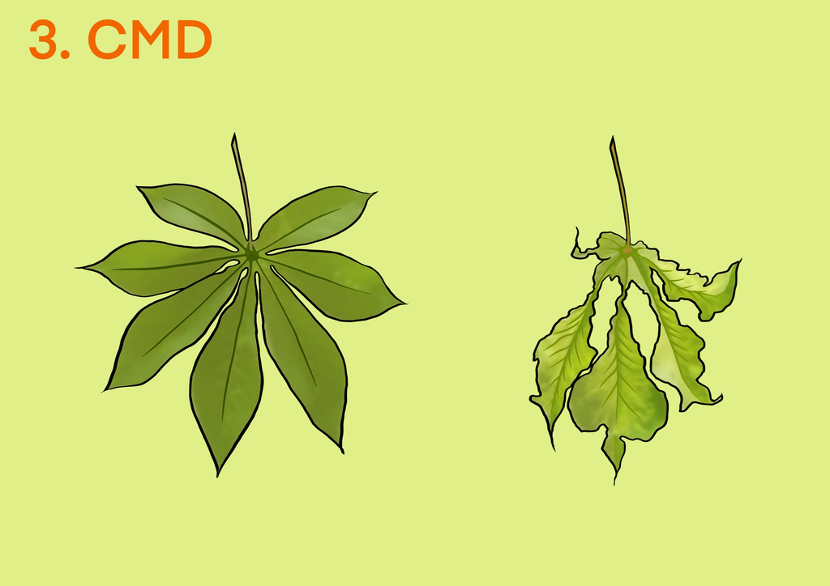

Cassava CMD

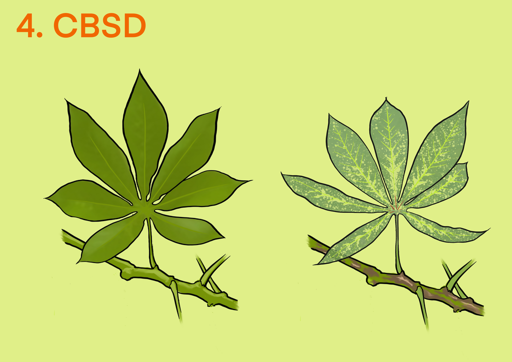

Cassava CBSD

#### Cocoa

#### Cowpea

#### Millet

#### Potato

#### Sorghum

#### Soybean

#### Other tricot materials